# Ford GoBike Data Analysis

## by Omar BOUGACHA

## Investigation Overview

In this presentation, I propose to compare some of the attributes of the Ford GoBike bike rides dataset. The aim is to present some of the insights of the data, compare the evolution of the performances, and give a support for future business decisions.

## Dataset Overview

After wrangling, the dataset of the bike rides information from the Ford GoBike is composed of:

- One table for bike rides for 2018 containing **1851950** entries with 8 features
- One table for bike rides for 2019 containing **2262979** entries with 8 features (Without the data of December)
- One table for stations' information for 2018 containing **331** entries with 4 features
- One table for stations' information for 2019 containing **428** entries with 4 features

## Analysis Overview

During this analysis, I propose to study the users' behaviour. Therefore, I investigate the following questions:

- How the duration of the bike ride are distributed?
- During which period(s) of the day there are more bike rides?
- What day(s) of the week present more bike rides?
- During which month(s) have the more dense bike usage?
- How is the flux of bike rides on some stations?
- How did all these performances evolve between 2018 and 2019?

## Duration Distributions

Here, we present the distributions of the bike rides' duration during 2018 and during 2019 to compare them. Please note that the distributions here are presented on a logarithmic scale.

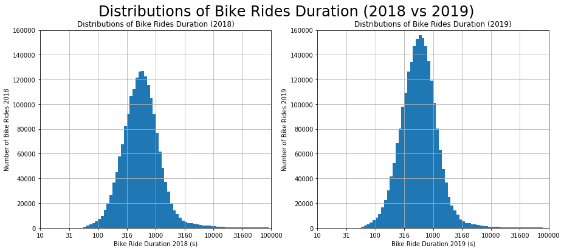

```python
plt.figure(figsize=(15,6))
log_dur_2018 = np.log10(gobike_2018_cln['duration_sec'])
log_dur_2019 = np.log10(gobike_2019_cln['duration_sec'])
plt.subplot(1,2,1)
bin_size_log = 0.05
bins_log =  np.arange(1, log_dur_2018.max()+bin_size_log, bin_size_log)
log_dur_2018.hist(bins=bins_log)
plt.ylim((0,160000))
plt.xlim((1, 5))
plt.xticks([1, 1.5, 2, 2.5, 3, 3.5, 4, 4.5, 5], [10, 31, 100, 316, 1000, 3160, 10000, 31600,100000])
plt.xlabel('Bike Ride Duration 2018 (s)')
plt.ylabel('Number of Bike Rides 2018')
plt.title('Distributions of Bike Rides Duration (2018)')
plt.subplot(1,2,2)
bin_size_log = 0.05
bins_log =  np.arange(1, log_dur_2019.max()+bin_size_log, bin_size_log)
log_dur_2019.hist(bins=bins_log)
plt.ylim((0,160000))
plt.xlim((1, 5))
plt.xticks([1, 1.5, 2, 2.5, 3, 3.5, 4, 4.5, 5], [10, 31, 100, 316, 1000, 3160, 10000, 31600,100000])
plt.xlabel('Bike Ride Duration 2019 (s)')
plt.ylabel('Number of Bike Rides 2019')
plt.title('Distributions of Bike Rides Duration (2019)')
plt.suptitle("Distributions of Bike Rides Duration (2018 vs 2019)", fontsize=24)
plt.show()
```

We can easily observe that we have the same distribution shape. And the same distribution characteristics (mean, mode, etc).

## Number of Rides per Hour of the Day

In this visualization we compare how the number of rides is distributed over the hours of the day. We choose to directly compare the distribution for 2018 and for 2019.

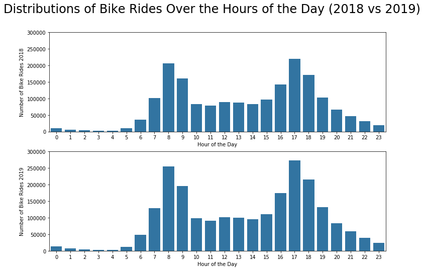

```python
fig, axs = plt.subplots(2,1)
fig.set_size_inches(12,8)
sns.catplot(x='hour_of_day',  data=gobike_2018_cln, height=6,
            aspect=2, kind='count', color = base_color, ax = axs[0])
axs[0].set_ylim((0, 300000))
axs[0].set_xlabel('Hour of the Day')
axs[0].set_ylabel('Number of Bike Rides 2018')
sns.catplot(x='hour_of_day',  data=gobike_2019_cln, height=6,
            aspect=2, kind='count', color = base_color, ax = axs[1])
axs[1].set_ylim((0, 300000))
axs[1].set_xlabel('Hour of the Day')
axs[1].set_ylabel('Number of Bike Rides 2019')
plt.close(2)
plt.close(3)
plt.suptitle("Distributions of Bike Rides Over the Hours of the Day (2018 vs 2019)", fontsize=24)
plt.show()
#fig.tight_layout()
```

We can note that the distribution of the bike rides over the hours of the day are bimodal for both years. The distribution has two peaks: one around 8 and the other around 17. These values correspond to the working hours start and end. However, we can think of solutions to improve the bike usage during the other hours of the day. Maybe Propose some lower costs.

## Number of Rides per Day of Week

In this visualization we compare how the number of rides is distributed over the days of the week. We choose to directly compare the distribution for 2018 and for 2019.

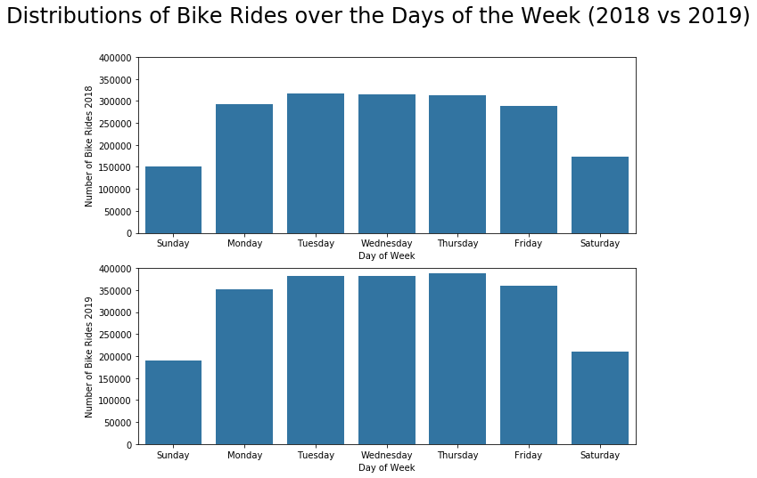

```python
fig, axs = plt.subplots(2,1)
fig.set_size_inches(10,8)
sns.catplot(x='day_of_week',  data=gobike_2018_cln, height=6,
            aspect=2, kind='count', color = base_color, ax = axs[0])
axs[0].set_ylim((0, 400000))
axs[0].set_xlabel('Day of Week')
axs[0].set_ylabel('Number of Bike Rides 2018')
sns.catplot(x='day_of_week',  data=gobike_2019_cln, height=6,
            aspect=2, kind='count', color = base_color, ax = axs[1])
axs[1].set_ylim((0, 400000))
axs[1].set_xlabel('Day of Week')
axs[1].set_ylabel('Number of Bike Rides 2019')
plt.close(2)
plt.close(3)
plt.suptitle("Distributions of Bike Rides over the Days of the Week (2018 vs 2019)", fontsize=24)
plt.show()
```

We can see that for both years the usage of the bike is at its most at the working days.

## Number of Rides per Month

In this visualization we compare how the number of rides is distributed over the months. We choose to directly compare the distribution for 2018 and for 2019. Please note that there is no value for the month of December 2019 because the data did not include the share bike status. So, I droped the missing values.

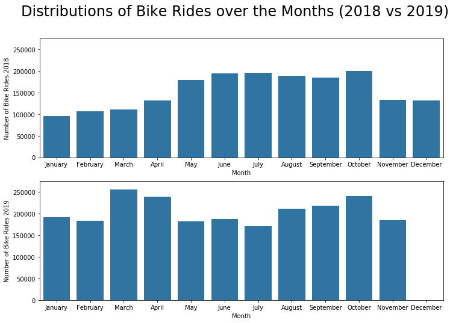

```python
fig, axs = plt.subplots(2,1)
fig.set_size_inches(12,8)
sns.catplot(x='month',  data=gobike_2018_cln, height=6,
            aspect=2, kind='count', color = base_color, ax = axs[0])
axs[0].set_ylim((0, 275000))
axs[0].set_xlabel('Month')
axs[0].set_ylabel('Number of Bike Rides 2018')
sns.catplot(x='month',  data=gobike_2019_cln, height=6,
            aspect=2, kind='count', color = base_color, ax = axs[1])
axs[1].set_ylim((0, 275000))
axs[1].set_xlabel('Month')
axs[1].set_ylabel('Number of Bike Rides 2019')
plt.close(2)
plt.close(3)
plt.suptitle("Distributions of Bike Rides over the Months (2018 vs 2019)", fontsize=24)
plt.show()
```

## Number of Rides per Type of User

In this visualization we compare how the number of rides is distributed according the type of user. We choose to directly compare the distribution for 2018 and for 2019.

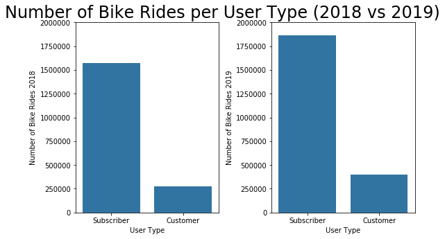

```python
fig, axs = plt.subplots(1,2)
fig.set_size_inches(8,5)
sns.catplot(x='user_type',  data=gobike_2018_cln, height=6,
            aspect=2, kind='count', color = base_color, ax = axs[0])
axs[0].set_ylim((0, 2000000))
axs[0].set_xlabel('User Type')
axs[0].set_ylabel('Number of Bike Rides 2018')
sns.catplot(x='user_type',  data=gobike_2019_cln, height=6,
            aspect=2, kind='count', color = base_color, ax = axs[1])
axs[1].set_ylim((0, 2000000))
axs[1].set_xlabel('User Type')
axs[1].set_ylabel('Number of Bike Rides 2019')
plt.close(2)
plt.close(3)
plt.suptitle("Number of Bike Rides per User Type (2018 vs 2019)", fontsize=24)
plt.tight_layout(rect=[0, 0.03, 1, 0.95])
plt.show()
```

## Stations' Arrival Departure Equilibrium:

Here, we indicat the station's with the highest (positive and negative) difference between the number of rides starting from them and the number of rides ending at them. We also compare these results of the two years.

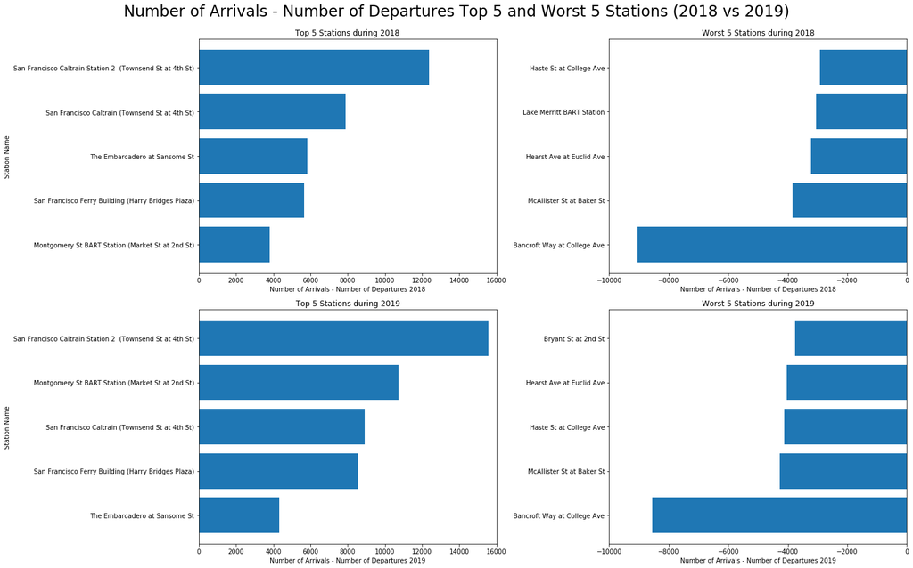

```python
plt.figure(figsize=(20,13))
ax = plt.subplot(2,2,1)
ax.barh(range(5), dep_arr_stat_2018['arr_dep'].values[-5:])
ax.set_xlim((0,16000))
ax.set_yticks(range(5))
ax.set_yticklabels(positive_2018)
ax.set_ylabel('Station Name')
ax.set_xlabel('Number of Arrivals - Number of Departures 2018')
ax.set_title('Top 5 Stations during 2018')
ax = plt.subplot(2,2,2)
ax.barh(range(5), dep_arr_stat_2018['arr_dep'].values[:5])
ax.set_xlim((-10000, 0))
ax.set_yticks(range(5))
ax.set_yticklabels(negative_2018)
ax.set_xlabel('Number of Arrivals - Number of Departures 2018')
ax.set_title('Worst 5 Stations during 2018')
ax = plt.subplot(2,2,3)
ax.barh(range(5), dep_arr_stat_2019['arr_dep'].values[-8:-3])
ax.set_xlim((0,16000))
ax.set_yticks(range(5))
ax.set_yticklabels(positive_2019)
ax.set_ylabel('Station Name')
ax.set_xlabel('Number of Arrivals - Number of Departures 2019')
ax.set_title('Top 5 Stations during 2019')
ax = plt.subplot(2,2,4)
ax.barh(range(5), dep_arr_stat_2019['arr_dep'].values[:5])
ax.set_xlim((-10000, 0))
ax.set_yticks(range(5))
ax.set_yticklabels(negative_2019)
ax.set_xlabel('Number of Arrivals - Number of Departures 2019')
ax.set_title('Worst 5 Stations during 2019')
plt.tight_layout(rect=[0, 0.03, 1, 0.95])
plt.suptitle("Number of Arrivals - Number of Departures Top 5 and Worst 5 Stations (2018 vs 2019)", fontsize=24)
plt.show()
```